# lab1

Zeyuan Fang

8/1/2021

upi:zfan253  
id:55658804

## Data Description

The data are counts of vehicles at different locations on state highways across New Zealand, provided in a file called lab01.csv

Every line in the file represents a count of the number of vehicles at a particular site during a 15-minute period. There are separate rows for different vehicle classes, heavy (H) and light (L), and separate rows for different “directions” (e.g., 1 and 2). The time period is described by the startDatetime and the endDatetime.

## 1

I may use the following commands to do this task :

mkdir lab1  
cd lab1  
After this, I can put the csv file into lab1 directory and also create a Rmd file in it.

## 2

```bash
du -sh lab01.csv
wc -l lab01.csv
```

```
##  22M lab01.csv
##   429689 lab01.csv
```

The size of the data file is about 22M and it contains 429689 lines.

## 3

```bash
grep '08-AUG-2020' lab01.csv | wc -l
```

```
##   141714
```

There are 141714 lines that contains 08-AUG-2020. For Lab Zero data, I may use  
grep ‘08-AUG-2020’ ../lab0/AugustTraffic-OLD.csv | wc -l  
command to evalute it, and there are also 141714 lines.

## 4

```bash
awk -F, '{print $3 }' lab01.csv| grep '08-AUG-2020'| wc -l
```

```
##   140152
```

There are 140152 lines whose start time is 08-AUG-2020, which mean there are 1562 lines whose start time is not 08-AUG-2020 but its end time is. Let us have a look one of them.

```bash
awk -F, '!match($3,/^08-AUG-2020/) && match($4,/^08-AUG-2020/) {print $0}' lab01.csv > output
head -n 1 output
```

```
## L,01N00526,07-AUG-2020 23:45,08-AUG-2020 00:00,2,7.5
```

## 5

```bash
awk -F, 'NR!=1 {print $1}' lab01.csv | sort|uniq -c
```

```
## 184220 H
## 245468 L
```

There are 184220 H and 245468 L, and there are not other values than H and L.

## 6

```bash
echo 'class,siteRef,startDatetime,endDatetime,direction,count' > August8.csv
 awk -F, '$3 ~ /^08-AUG-2020/ {print $0 }' lab01.csv >> August8.csv
 head August8.csv
 wc -l August8.csv
```

```
## class,siteRef,startDatetime,endDatetime,direction,count
## H,01600024,08-AUG-2020 13:15,08-AUG-2020 13:30,2,6
## H,01600024,08-AUG-2020 14:45,08-AUG-2020 15:00,2,5
## L,01600024,08-AUG-2020 19:00,08-AUG-2020 19:15,2,149
## L,03500332,08-AUG-2020 00:30,08-AUG-2020 00:45,2,2
## L,03500332,08-AUG-2020 03:15,08-AUG-2020 03:30,1,2
## H,03500332,08-AUG-2020 06:00,08-AUG-2020 06:15,2,1.5
## H,03500332,08-AUG-2020 15:45,08-AUG-2020 16:00,1,0
## L,00200428,08-AUG-2020 17:00,08-AUG-2020 17:15,2,16
## H,00200428,08-AUG-2020 21:30,08-AUG-2020 21:45,2,0
##   140153 August8.csv
```

First we write the col names into a new file called August8.csv, then we use awk to append data into this file.

## 7

```r
traffic <- read.csv('August8.csv')
head(traffic)
```

```
##   class  siteRef     startDatetime       endDatetime direction count
## 1     H 01600024 08-AUG-2020 13:15 08-AUG-2020 13:30         2   6.0
## 2     H 01600024 08-AUG-2020 14:45 08-AUG-2020 15:00         2   5.0
## 3     L 01600024 08-AUG-2020 19:00 08-AUG-2020 19:15         2 149.0
## 4     L 03500332 08-AUG-2020 00:30 08-AUG-2020 00:45         2   2.0
## 5     L 03500332 08-AUG-2020 03:15 08-AUG-2020 03:30         1   2.0
## 6     H 03500332 08-AUG-2020 06:00 08-AUG-2020 06:15         2   1.5
```

```r
dim(traffic)
```

```
## [1] 140152      6
```

The result is the same as the required.

## 8

```r
traffic$start <- as.POSIXlt(traffic$startDatetime,
                           format="08-AUG-2020 %H:%M")
table(traffic$start$mday)
```

```
##
##      2
## 140152
```

```r
traffic <- subset(traffic, start$hour >= 8 & start$hour <= 18)
traffic$scount <- sqrt(traffic$count)
```

In my enviroment, if I use the format “%d-%b-%Y %H:%M” then I will get NA for unknown reason. So I have to hard-code the fixed start day, which will work well for me.

## 9

```r
index <- sample(rep(1:10, length.out=nrow(traffic)))
train <- traffic[index > 1, ]
test <- traffic[index == 1, ]
RMSE <- function(obs, pred) {
    sqrt(mean((obs - pred)^2))
}
obs <- test$scount
predMean <- mean(train$scount)
lmfit1 <- lm(scount ~ class, train)
lmfit2 <- lm(scount ~ class+siteRef, train)
predLM1 <- predict(lmfit1, test)
predLM2 <- predict(lmfit2, test)
RMSE(obs, predLM1)
```

```
## [1] 5.204051
```

RMSE for Model with class

```r
RMSE(obs, predLM2)
```

```
## [1] 2.827101
```

RMSE for Model with class and siteRef

## 10

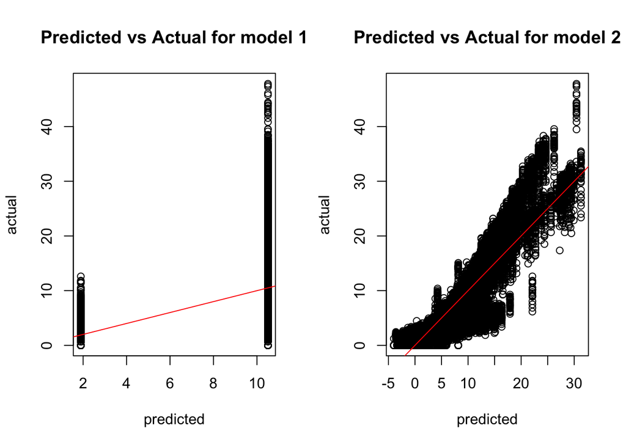

```r
par(mfrow = c(1, 2))
plot(fitted.values(lmfit1),train$scount, xlab="predicted",ylab="actual",main = "Predicted vs Actual for model 1")
abline(a=0,b=1,col='red')

plot(fitted.values(lmfit2),train$scount, xlab="predicted",ylab="actual",main = "Predicted vs Actual for model 2")
abline(a=0,b=1,col='red')
```

Clearly, the linear model with class and siteRef as regressors is better.